# MOVID - Quinto Informe de Participantes

[figure not shown]

**Miércoles 5 de agosto, 2020**

## Quinto informe de avance para participantes

Llevamos cuatro meses recolectando información semanal sobre el estado de salud de personas en el contexto de la crisis sanitaria por COVID-19 en Chile. Gracias a los aportes de los participantes MOVID-19, **hemos entregado a la Mesa Social COVID-19 nueve informes con propuestas concretas para abordar la crisis sanitaria**. Puede revisar todos nuestros informes en este vínculo.

En MOVID-19 reconocemos que la situación en Chile está avanzando y que debemos adaptarnos a las temáticas que vayan cobrando mayor relevancia en el tiempo. Por ello, durante las próximas semanas, realizaremos **algunas adaptaciones a las preguntas que hacemos semanalmente a nuestros participantes**. Sin embargo, antes de continuar con este gran esfuerzo, quisimos parar unos minutos a preguntarles a ustedes acerca de su experiencia contestando MOVID-19. En este informe reportamos las respuestas de 18.223 participantes MOVID-19 que nos dieron su opinión sobre el estudio. Con mucha alegría observamos que un **85% de los participantes está satisfecho o muy satisfecho con nuestro estudio** (Figura 1), mientras que un **96% está bastante o muy dispuesto a seguir participando en las próximas semanas** (Figura 2).

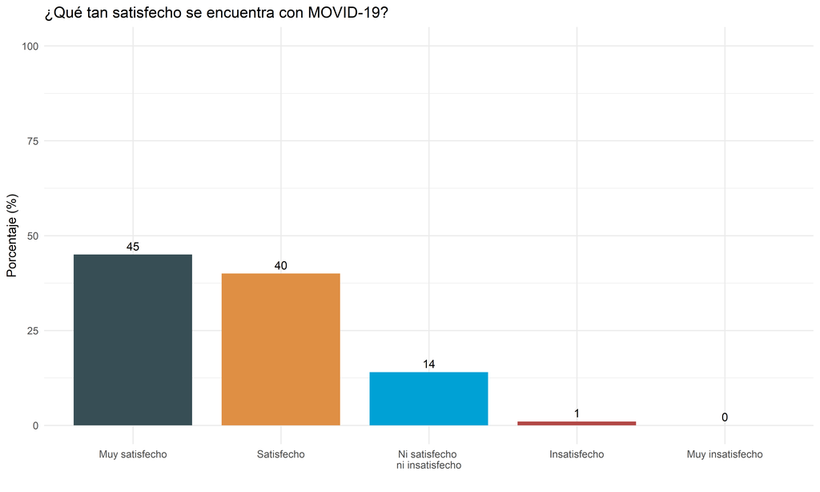

*Figura 1*. Satisfacción con MOVID-19. Análisis propio en base a datos MOVID-19 (n = 18.223).

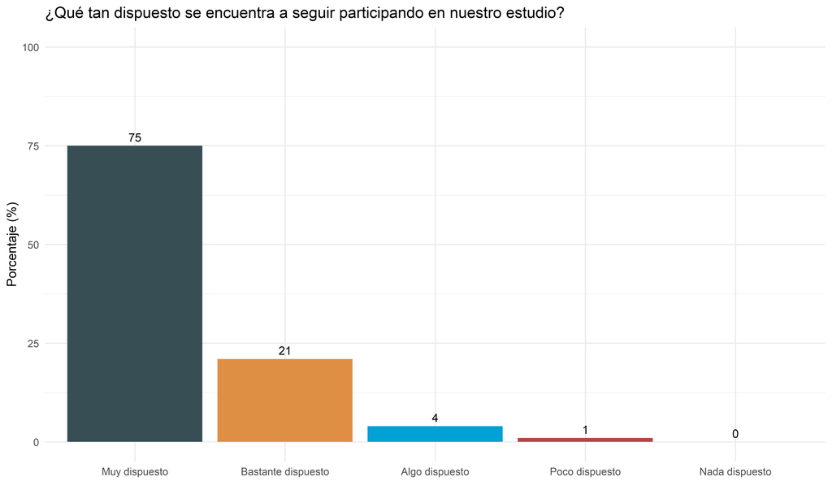

*Figura 2*. Disposición a seguir participando en MOVID-19. Análisis propio en base a datos MOVID-19 (n = 18.223).

También preguntamos acerca de la percepción de utilidad de los distintos productos que entregamos regularmente. Según las respuestas, son los **informes a la Mesa Social COVID-19** los productos considerados como más importantes, seguidos de los **recordatorios semanales** y las **recomendaciones personalizadas al final de la encuesta** (ver Figura 3). Recibimos también comentarios y sugerencias importantes de parte de los participantes MOVID-19. Nos encontramos en proceso de analizar esta información y les iremos contando acerca de lo que encontremos.

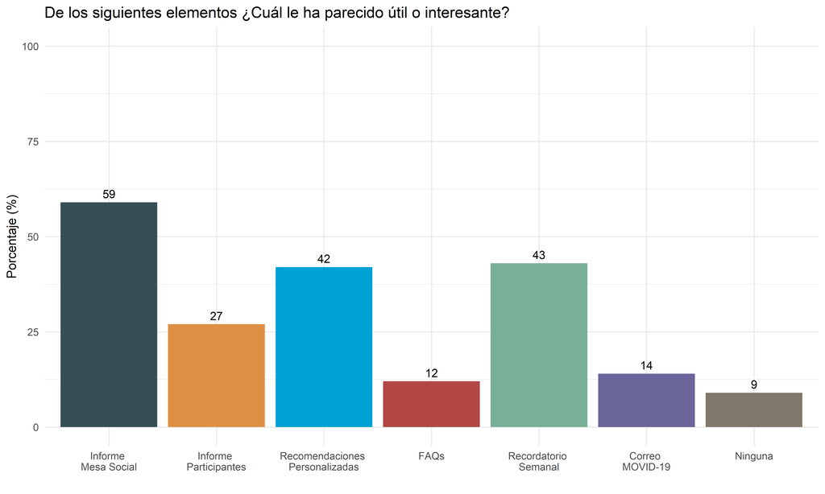

*Figura 3*. Percepción de utilidad o interés de distintos productos MOVID-19. Análisis propio en base a datos MOVID-19.

Volvemos a repetir nuestro **compromiso con la obtención de información valiosa para la comunidad y los tomadores de decisión** en el contexto de la pandemia que afecta nuestro país. A su vez, los invitamos a revisar nuestra página de [Preguntas Frecuentes](https://www.movid19.cl/FAQs.html) y todos nuestros informes en: [www.movid19.cl](https://www.movid19.cl/).

### Síntomas compatibles o situaciones de riesgo de tener COVID-19

Las siguientes situaciones son compatibles con enfermedad por COVID-19:

- Que aparezcan como síntomas nuevos, cualquier combinación de al menos dos de los siguientes síntomas: tos, diarrea, dolor de garganta (odinofagia) o dolor de cabeza (cefalea).
- Tener contacto estrecho con un paciente confirmado mediante PCR durante los últimos 14 días.
- Presentar fiebre (temperatura axilar mayor a 37.8ºC), sin otra causa evidente que pueda explicarlo.
- Presentar manifestación aguda de disminución o perdida del olfato (anosmia).

### Qué hacer si tiene síntomas compatibles con COVID-19

Cualquier persona que tenga sintomatología compatible con COVID-19 deberá iniciar de manera inmediata un aislamiento para evitar contagiar a otros. Esto implica evitar salir de su hogar, mantener distancia física de al menos dos metros con cualquier otra persona, usar mascarilla en todo momento, no compartir articulos personales con otros miembros del hogar. Así mismo, de ser posible debe evitar compartir habitación con otras personas. Con estas medidas usted estará contribuyendo a evitar que sus seres queridos u otras personas puedan contagiarse. Está en nosotros contribuir a disminuir el riesgo de contagios.

### Cómo seguir aportando

MOVID-19 está entregando información relevante para entender y controlar la crisis sanitaria que hoy está viviendo nuestro país. Para continuar este gran esfuerzo, necesitamos de su colaboración:

- Siga completando de manera semanal su situación actual de salud. Esta información es importante, sin importar si su situación ha cambiado o si se mantiene igual. Su actualización es fundamental aunque no tenga síntomas y esté cumpliendo con las medidas de aislamiento. Cuando sea el momento de contestar, le enviaremos un correo electrónico con una invitación dedicada para Ud.
- Invite a más personas a participar. Comparta el vínculo http://encuestacovid.uchile.cl en su comunidad, lugar de trabajo o estudio, a sus amigos o familia. Necesitamos llegar a la mayor cantidad de personas mayores de 18 años que viven en Chile.
- ¡Siga manteniendo distancia física y quédandose en casa lo más posible!

### ¡Esta pandemia la enfrentamos entre todas y todos!

Gracias por seguir participando en MOVID-19,

**Equipo MOVID-19**  
**Colegio Médico de Chile**  
**Universidad de Chile**

**Institución asociada: Facultad de Psicología, Universidad Diego Portales**

**Contacto: encuestacovid@uchile.cl**